# How Global Economies Have Evolved: Analyzing Centuries of Economic Data to Forecast Tomorrow’s Trends

1. Introduction
   - 1.1 Objective
   - 1.2 Scope and Relevance
   - 1.3 Methodology
   - 1.4 Data Sources
2. Data Collection and Preprocessing
   - 2.1 Loading the Data
   - 2.2 Data Cleaning and Transformation
   - 2.3 Handling Missing Values
   - 2.4 Merging Datasets
3. Exploratory Data Analysis (EDA)
   - 3.1 Summary Statistics
   - 3.2 Visualization of GDP Growth
   - 3.3 GDP and Population Correlations
   - 3.4 Regional Comparison
4. Time-Series Analysis
   - 4.1 Decomposition of GDP Data
   - 4.2 ARIMA for GDP Forecasting
5. Regression and Causal Inference
   - 5.1 Multiple Regression Analysis
   - 5.2 Causal Relationships
6. Forecasting Economic Trends
   - 6.1 Predicting Future GDP Growth
   - 6.2 Scenario Analysis
7. Clustering Countries Based on Economic Indicators
   - 7.1 K-Means Clustering
   - 7.2 Cluster Analysis Results
8. Results, Insights, and Policy Implications
   - 8.1 Key Findings
   - 8.2 Implications for Economic Policy
9. Conclusion
   - 9.1 Summary of Results
   - 9.2 Future Work
10. References
    - 10.1 Maddison Project Data Citation
    - 10.2 Other Data Sources

# 1. Introduction

### 1.1 Objective

This project aims to analyze the evolution of global economies over a period spanning two millennia, using historical data on GDP, population growth, and other economic indicators. By leveraging the Maddison Project Database, which provides comprehensive long-term data on economic growth, this study investigates how different regions and countries have developed economically over time. By investigating key historical periods, such as the Industrial Revolution, the two World Wars, and periods of economic crises, this study aims to uncover underlying patterns and trends that have shaped the current global economic landscape. Furthermore, this research will employ modern statistical and machine learning techniques to forecast future economic trends, providing insights that may inform current policy decisions and future economic planning.

Economic history has long been an essential area of study. Scholars like Angus Maddison, who pioneered long-term economic history analysis, have shown that the history of human economic development is marked by substantial changes, such as the Agricultural Revolution, the Industrial Revolution, and the Globalization Era. Each of these transformative periods reshaped global economies and resulted in significant shifts in the economic power balance. This project builds upon such academic work, delving into both global trends and specific country/region-level shifts. Furthermore, this analysis extends beyond merely historical understanding; it also incorporates predictive models to forecast future trends based on patterns identified in the historical data.

The project will also examine the economic impact of seminal historical occurrences, such as the Roman Empire's rise and fall, the Black Death, the two World Wars, and the post-WWII economic recovery. These events shaped economies in profound ways, and understanding their long-term effects can provide invaluable insights into how global economies respond to major disruptions. Additionally, this project aims to inform current and future policy decisions by offering predictions about economic growth based on lessons from the past.

### 1.2 Scope and Relevance

The scope of this project spans 2000 years, covering the development of economies from the early days of the Roman Empire to modern global capitalism. This extensive time span is crucial because it allows for an exploration of the long-term drivers of economic change, including technological advancements, population growth, trade dynamics, and geopolitical factors. Historical economic trends provide a perspective that short-term analyses simply cannot capture, as economic processes such as industrialization, technological revolutions, and political shifts unfold over long periods. Understanding these long-term dynamics is particularly important as we face challenges such as climate change, global inequality, and technological disruption that have the potential to reshape economies in unforeseen ways.

The long-term perspective offered by this analysis is rooted in the academic tradition established by economic historians such as Robert Allen, who explored the economic history of the Industrial Revolution, and Fernand Braudel, who emphasized the importance of historical structures and geographical factors in shaping long-term economic trends. Their work highlights the need to examine historical data through a holistic lens, considering not only immediate factors but also social, political, and cultural forces that have influenced economic systems over time.

Moreover, the relevance of this study extends beyond academic curiosity. By investigating historical economic trends, we can better understand the economic foundations of modern economies and the structural inequalities that persist today. This understanding is essential for developing policies that can address global challenges, including income inequality, sustainable economic growth, and the ongoing process of globalization. As noted by Thomas Piketty in his seminal book *Capital in the Twenty-First Century*, understanding the historical evolution of wealth distribution is crucial for addressing contemporary economic issues.

### 1.3 Methodology

This project utilizes a combination of traditional economic analysis and modern data science techniques to analyze the historical data. The analysis begins with a thorough review of GDP and population data from the Maddison Project, supplemented by data from the World Bank and OECD Economic Outlook. The data will be analyzed using time-series techniques, including decomposition to break down long-term trends, seasonality, and cyclical patterns that influence economic performance.

To gain a deeper understanding of the relationships between economic growth and key factors, multiple regression models will be employed. These models will allow for the identification of the primary drivers of GDP growth, including variables such as technological progress, trade integration, and human capital accumulation. Moreover, causal inference techniques, particularly Do-Calculus and counterfactual analysis, will be applied to assess the causal impact of significant historical events, such as wars, pandemics, and technological revolutions, on long-term economic growth.

Another critical component of this project is the use of machine learning algorithms to predict future trends. By applying models such as ARIMA and LSTM (Long Short-Term Memory) networks, the project aims to forecast future GDP growth based on historical data. These models are particularly useful for time-series data, allowing for accurate forecasting and the identification of future economic cycles.

Furthermore, clustering algorithms such as K-Means will be used to group countries with similar economic characteristics. This will allow for a comparative analysis of economic performance across regions and provide insights into how different economic systems have responded to historical events.

### 1.4 Data Sources

The primary data sources for this analysis are the Maddison Project Database, which provides the most comprehensive long-term data on global GDP, population, and other economic indicators, and World Bank Historical Data, which offers supplementary data on trade, inflation, and poverty rates. The OECD Economic Outlook provides additional insights into more recent economic trends and projections, particularly for the post-World War II period. These datasets are complemented by regional GDP and population estimates, which will allow for a more granular analysis of specific countries and regions.

The Maddison Project Database offers data covering more than 100 countries and regions over a span of 2000 years, making it an invaluable resource for understanding global economic history. Additionally, the World Bank provides high-quality data that allows for comparisons across different economic systems and offers insights into contemporary issues such as global inequality and economic crises. By leveraging these diverse data sources, this project seeks to provide a comprehensive examination of global economic trends and their implications for future economic policies.

### Author Information

This project is authored by Dr. Eskinder Belete, a data scientist with a doctorate in Data Analytics/Data Science and an MBA. With over 10 years of experience in data science, machine learning, and economic analysis, Dr. Belete has worked on a variety of projects spanning multiple domains, including historical economic analysis, AI-based forecasting, and predictive modeling. As an adjunct professor of Data Science and AI, Dr. Belete is passionate about bridging the gap between advanced data analytics and real-world applications, particularly in the fields of economic history and policy analysis.

Through this project, Dr. Belete aims to contribute to the growing field of quantitative economic history, providing insights that can inform both modern economic policy and future economic planning.

# 2. Data Collection and Preprocessing

In this section, we will focus on the collection, cleaning, and preprocessing of the historical economic data that will form the foundation of our analysis. The datasets used for this project are sourced from the Maddison Project Database, which provides comprehensive data on global GDP, population, and other economic indicators spanning over two millennia.

The following data files will be used:

1. **Global GDP and Population Data**: The primary dataset containing global GDP and population data across multiple centuries.
2. **Regional GDP per Capita Data**: This dataset contains GDP per capita data by region.
3. **Regional Population Estimates**: This dataset provides population estimates by region.

Before performing any analysis, it is crucial to load and clean the data to ensure its consistency and accuracy. This includes handling missing values, checking for anomalies, and transforming the data into a suitable format for further analysis.

## 2.1 Loading the Data

The first step is to load the datasets into the Jupyter notebook using Python's **Pandas** library. We will use the file paths provided for each dataset to load them into **Pandas DataFrames** for further exploration and preprocessing.

We will also import the necessary libraries for this project, including **Pandas** for data manipulation, and other essential libraries like **Matplotlib** and **Seaborn** for visualization, and **NumPy** for numerical operations.

After loading the data, we will examine the first few rows of each dataset to ensure the data has been correctly loaded and is in a usable format.

```python
# Import necessary libraries
import pandas as pd
import numpy as np
import matplotlib.pyplot as plt
import seaborn as sns

# Load the datasets into Pandas DataFrames
gdp_data = pd.read_excel(file_path_gdp)
gdp_per_capita = pd.read_excel(file_path_gdp_per_capita)
population_data = pd.read_excel(file_path_population)

# Display the first few rows of each dataset to ensure proper loading
print("GDP Data:")
print(gdp_data.head())

print("\nGDP per Capita Data:")
print(gdp_per_capita.head())

print("\nPopulation Data:")
print(population_data.head())
```

```
GDP Data:
  Country Code      Country                     Region  Year  GDP PC  \
0          AFG  Afghanistan  South and South East Asia     1     NaN
1          AFG  Afghanistan  South and South East Asia   730     NaN
2          AFG  Afghanistan  South and South East Asia  1000     NaN
3          AFG  Afghanistan  South and South East Asia  1090     NaN
4          AFG  Afghanistan  South and South East Asia  1150     NaN

   Population
0         NaN
1         NaN
2         NaN
3         NaN
4         NaN

GDP per Capita Data:
   Year   East Asia  Eastern Europe  Latin America  \
0  1820  911.159926     1044.538462     956.907120
1  1830  846.000000             NaN     925.000000
2  1840  849.000000             NaN    1081.000000
3  1850  899.657658     1290.561798    1067.858361
4  1860         NaN             NaN    1588.000000

   Middle East and North Africa  South and South East Asia  \
0                    885.899599                 919.201211
1                           NaN                 934.895891
2                           NaN                 938.789859
3                           NaN                 926.960126
4                           NaN                 888.648973

   Sub Saharan Africa  Western Europe  Western Offshoots  World GDP PC
0              1188.0     2170.704817        2513.045418   1127.729974
1                 NaN     2314.693145        2886.763228           NaN
2                 NaN     2528.164800        3167.864246           NaN
3                 NaN     2670.193221        3474.410149   1300.501949
4                 NaN     3028.877334        4214.440703           NaN

Population Data:
   Year  East Asia  Eastern Europe  Latin America  \
0  1820   427757.0         91222.0        20704.0
1  1830        NaN             NaN            NaN
2  1840        NaN             NaN            NaN
3  1850   455774.0        118161.0        30671.0
4  1860        NaN             NaN            NaN

   Middle East and North Africa  South and South East Asia  Sub Saharan SSA  \
0                       35936.0                   255695.0          60000.0
1                           NaN                        NaN              NaN
2                           NaN                        NaN              NaN
3                       42000.0                   278706.0          65000.0
4                           NaN                        NaN              NaN

   Western Europe  Western Offshoots  World Population
0        139472.0            11231.0         1042017.0
1             NaN                NaN               NaN
2             NaN                NaN               NaN
3        172226.0            26760.0         1189298.0
4             NaN                NaN               NaN
```

## 2.2 Data Cleaning and Transformation

Once the datasets are loaded into the notebook, it is important to clean and preprocess the data before performing any analysis. This step ensures that the data is consistent, accurate, and in a suitable format for analysis. In this section, we will focus on:

1. **Handling Missing Values**: Missing data can be problematic for analysis. We will check for any missing values in each dataset and decide on appropriate strategies to handle them, such as filling missing values with the mean, median, or removing rows with missing data.
2. **Data Type Conversion**: Ensuring that each column has the correct data type (e.g., converting columns to numeric, date, or string as necessary). For instance, columns representing years should be in the correct date format, while numerical data should be in a consistent numeric format.
3. **Outlier Detection**: Identifying any extreme outliers in the data that could distort the analysis. We will apply techniques like z-scores or interquartile range (IQR) to detect outliers and assess their impact on the dataset.
4. **Normalization and Standardization**: To ensure the data is comparable across different regions and time periods, we may need to normalize or standardize the data, especially for variables like GDP per capita, which vary significantly between regions.
5. **Feature Engineering**: We may create new columns based on existing data. For example, calculating GDP growth rates or creating new categorical variables based on region or time period.

By performing these transformations, we can ensure that the data is ready for further analysis, which will lead to more accurate and meaningful insights.

```python
# Checking the first few rows of the 'Year' column to inspect any problematic values
print("Checking 'Year' column values in Global GDP and Population Data:")
print(gdp_data['Year'].head())

print("\nChecking 'Year' column values in Regional GDP per Capita Data:")
print(gdp_per_capita['Year'].head())

print("\nChecking 'Year' column values in Regional Population Estimates:")
print(population_data['Year'].head())

# Converting 'Year' columns to datetime format for consistency
# Using 'errors="coerce"' to handle any values that don't match the format
gdp_data['Year'] = pd.to_datetime(gdp_data['Year'], format='%Y', errors='coerce')
gdp_per_capita['Year'] = pd.to_datetime(gdp_per_capita['Year'], format='%Y', errors='coerce')
population_data['Year'] = pd.to_datetime(population_data['Year'], format='%Y', errors='coerce')

# Checking the conversion results to ensure proper handling of invalid years
print("\nAfter Conversion, checking 'Year' column values in Global GDP and Population Data:")
print(gdp_data['Year'].head())

print("\nAfter Conversion, checking 'Year' column values in Regional GDP per Capita Data:")
print(gdp_per_capita['Year'].head())

print("\nAfter Conversion, checking 'Year' column values in Regional Population Estimates:")
print(population_data['Year'].head())

# Display the cleaned data to ensure that 'Year' has been properly converted and handled
print("\nCleaned Global GDP and Population Data:")
print(gdp_data.head())

print("\nCleaned Regional GDP per Capita Data:")
print(gdp_per_capita.head())

print("\nCleaned Regional Population Estimates:")
print(population_data.head())
```

```
Checking 'Year' column values in Global GDP and Population Data:
0       1
1     730
2    1000
3    1090
4    1150
Name: Year, dtype: int64

Checking 'Year' column values in Regional GDP per Capita Data:
0    1820
1    1830
2    1840
3    1850
4    1860
Name: Year, dtype: int64

Checking 'Year' column values in Regional Population Estimates:
0    1820
1    1830
2    1840
3    1850
4    1860
Name: Year, dtype: int64

After Conversion, checking 'Year' column values in Global GDP and Population Data:
0   NaT
1   NaT
2   NaT
3   NaT
4   NaT
Name: Year, dtype: datetime64[ns]

After Conversion, checking 'Year' column values in Regional GDP per Capita Data:
0   1820-01-01
1   1830-01-01
2   1840-01-01
3   1850-01-01
4   1860-01-01
Name: Year, dtype: datetime64[ns]

```

[output cut: 51 more lines]

```
4 1860-01-01        NaN             NaN            NaN

   Middle East and North Africa  South and South East Asia  Sub Saharan SSA  \
0                       35936.0                   255695.0          60000.0
1                           NaN                        NaN              NaN
2                           NaN                        NaN              NaN
3                       42000.0                   278706.0          65000.0
4                           NaN                        NaN              NaN

   Western Europe  Western Offshoots  World Population
0        139472.0            11231.0         1042017.0
1             NaN                NaN               NaN
2             NaN                NaN               NaN
3        172226.0            26760.0         1189298.0
4             NaN                NaN               NaN
```

## 2.3 Handling Missing Values

In any real-world dataset, missing values are a common issue that must be addressed before performing meaningful analysis. Missing data can introduce bias and distort the results if not handled properly. This section discusses how we handle missing values in the datasets to ensure that the analysis remains accurate.

### 1. **Identifying Missing Values**

We first check for missing values across all datasets. The missing values could occur in columns like **GDP per capita**, **population**, or **World GDP**. Identifying the missing values early on allows us to apply appropriate strategies.

### 2. **Handling Missing Values in Numerical Data**

For numerical columns such as **GDP**, **GDP per capita**, and **population**, we typically handle missing values by applying one of the following strategies:

- **Imputation**: Filling in missing values with the **mean**, **median**, or **mode** based on the distribution of the data.
- **Removal**: Removing rows with missing values if they are too numerous and could distort the analysis.

### 3. **Handling Missing Values in Categorical Data**

For categorical data (such as regions or countries), we may apply different strategies:

- **Removal**: If a large portion of categorical data is missing, we may remove the rows.
- **Imputation**: Alternatively, we may fill missing categorical data with the most common category.

### 4. **Verifying Cleaned Data**

After handling missing values, we ensure that no critical columns have missing data and verify that our approach to imputation or removal did not distort the dataset.

By following these steps, we aim to ensure that missing values do not compromise the quality or accuracy of our analysis.

```python
# Handling Missing Values

# Checking for missing values in each dataset
print("Checking for missing values in Global GDP and Population Data:")
print(gdp_data.isnull().sum())

print("\nChecking for missing values in Regional GDP per Capita Data:")
print(gdp_per_capita.isnull().sum())

print("\nChecking for missing values in Regional Population Estimates:")
print(population_data.isnull().sum())

# Handling missing values: filling with median or removing rows with missing data as needed

# 1. For GDP data and GDP per capita, we will fill missing values with the median
# Apply fillna only on numeric columns
gdp_data_numeric = gdp_data.select_dtypes(include=[np.number])
gdp_data[gdp_data_numeric.columns] = gdp_data_numeric.fillna(gdp_data_numeric.median())

# Similarly for GDP per capita data
gdp_per_capita_numeric = gdp_per_capita.select_dtypes(include=[np.number])
gdp_per_capita[gdp_per_capita_numeric.columns] = gdp_per_capita_numeric.fillna(gdp_per_capita_numeric.median())

# 2. For Population data, we will remove rows with missing population values
# Removing rows with missing population data for better accuracy
population_data.dropna(subset=['World Population'], inplace=True)  # Removing rows with missing population data

# 3. Checking the result after handling missing values
print("\nCleaned Global GDP and Population Data:")
print(gdp_data.head())

print("\nCleaned Regional GDP per Capita Data:")
print(gdp_per_capita.head())

print("\nCleaned Regional Population Estimates:")
print(population_data.head())

# Now, we will merge the datasets on the 'Year' column
merged_data = pd.merge(gdp_data, population_data, on='Year', how='inner')  # Merging GDP and Population Data
merged_data = pd.merge(merged_data, gdp_per_capita, on='Year', how='inner')  # Merging with GDP per Capita Data

# Checking the merged dataset for consistency
print("\nMerged Dataset:")
print(merged_data.head())

# Final check to verify that no critical columns have missing values after merging
print("\nFinal Check for Missing Values in Merged Data:")
print(merged_data.isnull().sum())
```

```
Checking for missing values in Global GDP and Population Data:
Country Code         0
Country              0
Region               0
Year             72839
GDP PC          109778
Population      113269
dtype: int64

Checking for missing values in Regional GDP per Capita Data:
Year                             0
East Asia                        2
Eastern Europe                   4
Latin America                    0
Middle East and North Africa     9
South and South East Asia        0
Sub Saharan Africa              10
Western Europe                   0
Western Offshoots                0
World GDP PC                     7
dtype: int64

Checking for missing values in Regional Population Estimates:
Year                            0
East Asia                       7
Eastern Europe                  7
Latin America                   7
Middle East and North Africa    7
South and South East Asia       7
Sub Saharan SSA                 7
Western Europe                  7
Western Offshoots               7
World Population                7
dtype: int64

Cleaned Global GDP and Population Data:
  Country Code      Country                     Region Year       GDP PC  \
0          AFG  Afghanistan  South and South East Asia  NaT  2598.126396
1          AFG  Afghanistan  South and South East Asia  NaT  2598.126396
2          AFG  Afghanistan  South and South East Asia  NaT  2598.126396
```

[output cut: 110 more lines]

```
South and South East Asia_x       0
Sub Saharan SSA                   0
Western Europe_x                  0
Western Offshoots_x               0
World Population                  0
East Asia_y                       0
Eastern Europe_y                  0
Latin America_y                   0
Middle East and North Africa_y    0
South and South East Asia_y       0
Sub Saharan Africa                0
Western Europe_y                  0
Western Offshoots_y               0
World GDP PC                      0
dtype: int64
```

## 2.4 Merging Datasets

In this section, we will merge the datasets that we have cleaned in the previous steps: Global GDP and Population Data, Regional GDP per Capita Data, and Regional Population Estimates. The purpose of this step is to combine all relevant economic indicators (such as GDP, GDP per capita, and population) for each year, across different regions, into a unified dataset.

#### 1. Identifying Common Columns for Merging

The common column across all three datasets is 'Year', which will serve as the key for merging the data. We will merge the datasets based on this column to align the economic data over time.

#### 2. Choosing the Merge Strategy

We will use an **inner join** to ensure that only the rows with matching Year values from all datasets are included. This guarantees that only the years present in all three datasets will be kept in the merged dataset.

#### 3. Verifying the Merged Dataset

After merging, we will check the resulting dataset for consistency, making sure that no rows have been lost due to mismatches in the Year column. We will also check for any missing values that may have been introduced during the merge.

By the end of this section, we will have a comprehensive dataset containing GDP, GDP per capita, and population data for each year, ready for further analysis.

```python
# Merging Datasets

# Merging GDP Data and Population Data on 'Year'
merged_data = pd.merge(gdp_data, population_data, on='Year', how='inner')  # Merge GDP and Population Data
print("\nMerged GDP and Population Data:")
print(merged_data.head())

# Merging with GDP per Capita Data on 'Year'
merged_data = pd.merge(merged_data, gdp_per_capita, on='Year', how='inner')  # Merge with GDP per Capita Data
print("\nMerged Dataset with GDP per Capita Data:")
print(merged_data.head())

# Checking for any missing values after merging the datasets
print("\nChecking for missing values in the merged dataset:")
print(merged_data.isnull().sum())

# Verifying the consistency of the merged dataset (ensure all columns are aligned)
print("\nFinal Merged Dataset Preview:")
print(merged_data.head())
```

```
Merged GDP and Population Data:
  Country Code      Country                     Region       Year  \
0          AFG  Afghanistan  South and South East Asia 1820-01-01
1          AFG  Afghanistan  South and South East Asia 1850-01-01
2          AFG  Afghanistan  South and South East Asia 1870-01-01
3          AFG  Afghanistan  South and South East Asia 1900-01-01
4          AFG  Afghanistan  South and South East Asia 1920-01-01

        GDP PC  Population  East Asia  Eastern Europe  Latin America  \
0  2598.126396      3280.0   427757.0         91222.0        20704.0
1  2598.126396      5972.0   455774.0        118161.0        30671.0
2  2598.126396      4207.0   409153.0        142229.0        39023.0
3  2598.126396      5972.0   457058.0        195493.0        62662.0
4  2598.126396      5972.0   543904.0        230270.0        87509.0

   Middle East and North Africa  South and South East Asia  Sub Saharan SSA  \
0                       35936.0              255695.000000          60000.0
1                       42000.0              278706.000000          65000.0
2                       45868.0              327692.000000          70000.0
3                       56000.0              366060.000000          86000.0
4                       71000.0              514139.803922         105000.0

   Western Europe  Western Offshoots  World Population
0        139472.0            11231.0      1.042017e+06
1        172226.0            26760.0      1.189298e+06
2        191985.0            46088.0      1.272038e+06
3        236902.0            86396.0      1.546571e+06
4        261053.0           122278.0      1.935154e+06

Merged Dataset with GDP per Capita Data:
  Country Code      Country                     Region       Year  \
0          AFG  Afghanistan  South and South East Asia 1820-01-01
1          AFG  Afghanistan  South and South East Asia 1850-01-01
2          AFG  Afghanistan  South and South East Asia 1870-01-01
3          AFG  Afghanistan  South and South East Asia 1900-01-01
4          AFG  Afghanistan  South and South East Asia 1920-01-01

        GDP PC  Population  East Asia_x  Eastern Europe_x  Latin America_x  \
0  2598.126396      3280.0     427757.0           91222.0          20704.0
1  2598.126396      5972.0     455774.0          118161.0          30671.0
```

[output cut: 90 more lines]

```
   South and South East Asia_y  Sub Saharan Africa  Western Europe_y  \
0                   919.201211         1188.000000       2170.704817
1                   926.960126         2620.640953       2670.193221
2                   850.244997         1286.000000       3287.760602
3                   997.547187         2620.640953       4724.007472
4                  1117.526720         2620.640953       4869.033046

   Western Offshoots_y  World GDP PC
0          2513.045418   1127.729974
1          3474.410149   1300.501949
2          4647.453901   1543.226677
3          7740.850451   2265.468726
4          9741.422761   2493.315221

[5 rows x 24 columns]
```

## 3. Exploratory Data Analysis (EDA)

Exploratory Data Analysis (EDA) is a foundational step in data science that allows researchers to examine, summarize, and visualize the key characteristics of a dataset before conducting formal modeling or hypothesis testing. In the context of long-term economic analysis, EDA helps us uncover underlying structures in GDP, population, and regional dynamics across centuries, while identifying patterns, anomalies, and interdependencies that inform broader economic narratives.

In this section, we focus on four primary objectives:

- Understanding the distribution of key economic variables, including GDP per capita, population, and total GDP (GDP per capita × population), across time and space.
- Exploring historical trends, such as industrialization, demographic expansion, and economic divergence, by plotting indicators over time.
- Comparing regions, using boxplots to highlight disparities in economic outcomes and demographic scale between different parts of the world.
- Detecting outliers and skewness, which often point to structural transitions, major geopolitical shifts, or statistical irregularities.

```
Columns in gdp_data: Index(['Country Code', 'Country', 'Region', 'Year', 'gdppc', 'population'], dtype='object')
```

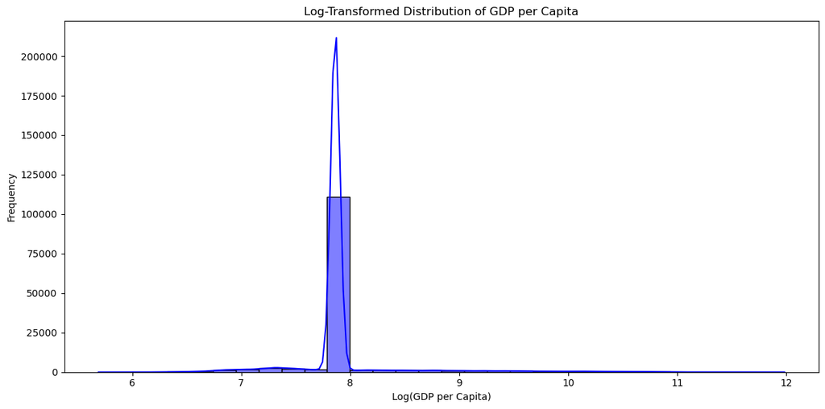

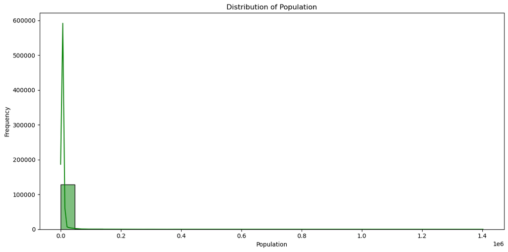

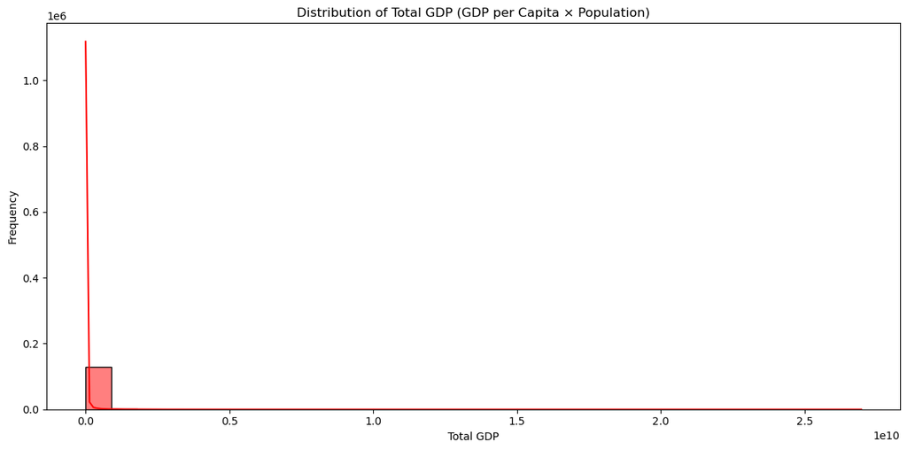

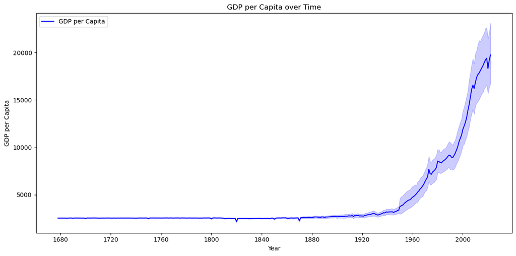

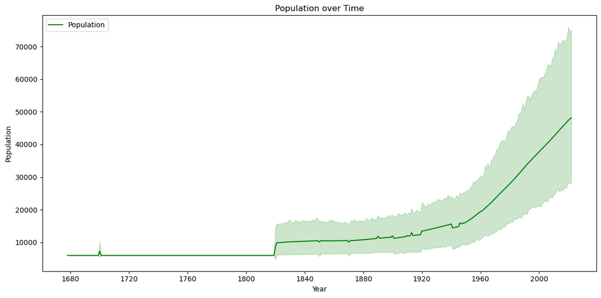

[figure not shown]

[figure not shown]

```python
import pandas as pd
import numpy as np
import matplotlib.pyplot as plt
import seaborn as sns
from IPython.display import display

# --- Improve plot display ---
plt.rcParams['figure.dpi'] = 100

# --- Assuming gdp_data, gdp_per_capita, population_data are already loaded ---

# --- Step 1: Inspect and rename columns if necessary ---
print("Columns in gdp_data:", gdp_data.columns)

gdp_data = gdp_data.rename(columns={
    'GDP PC': 'gdppc',
    'Population': 'population',
    'Year': 'Year'
})

# --- Step 2: Rename region-level columns ---
gdp_per_capita.columns = ['Year', 1, 2, 3, 4, 5, 6, 7, 8, 'World GDP pc']
population_data.columns = ['Year', 1, 2, 3, 4, 5, 6, 7, 8, 'World Population']

# --- Step 3: region_mapping definition ---
region_mapping = {
    1: 'North America',
    2: 'Europe',
    3: 'Asia',
    4: 'South America',
    5: 'Africa',
    6: 'Oceania',
    7: 'Middle East',
    8: 'Other'
}

# --- Step 4: GDP per Capita Distribution ---
plt.figure(figsize=(12, 6))
sns.histplot(np.log1p(gdp_data['gdppc']), kde=True, bins=30, color='blue')
plt.title('Log-Transformed Distribution of GDP per Capita')
plt.xlabel('Log(GDP per Capita)')
plt.ylabel('Frequency')
# plt.savefig("gdp_pc_distribution.png", bbox_inches='tight')
plt.tight_layout()
plt.show()

# --- Step 5: Population Distribution ---
plt.figure(figsize=(12, 6))
sns.histplot(gdp_data['population'], kde=True, bins=30, color='green')
plt.title('Distribution of Population')
plt.xlabel('Population')
plt.ylabel('Frequency')
# plt.savefig("population_distribution.png", bbox_inches='tight')
plt.tight_layout()
plt.show()

# --- Step 6: Total GDP Distribution ---
plt.figure(figsize=(12, 6))
sns.histplot(gdp_data['gdppc'] * gdp_data['population'], kde=True, bins=30, color='red')
plt.title('Distribution of Total GDP (GDP per Capita × Population)')
plt.xlabel('Total GDP')
plt.ylabel('Frequency')
# plt.savefig("total_gdp_distribution.png", bbox_inches='tight')
plt.tight_layout()
plt.show()

# --- Step 7: GDP per Capita Over Time ---
plt.figure(figsize=(12, 6))
sns.lineplot(data=gdp_data, x='Year', y='gdppc', label='GDP per Capita', color='blue')
plt.title('GDP per Capita over Time')
plt.xlabel('Year')
plt.ylabel('GDP per Capita')
# plt.savefig("gdp_over_time.png", bbox_inches='tight')
plt.tight_layout()
plt.show()

# --- Step 8: Population Over Time ---
plt.figure(figsize=(12, 6))
sns.lineplot(data=gdp_data, x='Year', y='population', label='Population', color='green')
plt.title('Population over Time')
plt.xlabel('Year')
plt.ylabel('Population')
# plt.savefig("population_over_time.png", bbox_inches='tight')
plt.tight_layout()
plt.show()

# --- Step 9: GDP per Capita by Region ---
plt.figure(figsize=(12, 6))
sns.boxplot(data=gdp_per_capita[[1, 2, 3, 4, 5, 6, 7, 8]], palette="Set2")
plt.title('GDP per Capita Distribution by Region (Numeric Labels)')
plt.ylabel('GDP per Capita')
plt.legend(
    labels=[f'{num} - {region}' for num, region in region_mapping.items()],
    title='Region',
    loc='upper left',
    bbox_to_anchor=(1, 1)
)
# plt.savefig("gdp_by_region.png", bbox_inches='tight')
plt.tight_layout()
plt.show()

# --- Step 10: Population by Region ---
plt.figure(figsize=(12, 6))
sns.boxplot(data=population_data[[1, 2, 3, 4, 5, 6, 7, 8]], palette="Set2")
plt.title('Population Distribution by Region (Numeric Labels)')
plt.ylabel('Population')
plt.legend(
    labels=[f'{num} - {region}' for num, region in region_mapping.items()],
    title='Region',
    loc='upper left',
    bbox_to_anchor=(1, 1)
)
# plt.savefig("population_by_region.png", bbox_inches='tight')
plt.tight_layout()
plt.show()
```

##### Interpretation of the Visuals

The first series of plots reveals the highly skewed nature of GDP and population distributions, especially in modern periods. The log-transformed GDP per capita distribution helps reveal the central mass of values and isolates outlier economies with extremely high income levels. Similarly, the population distribution underscores the massive demographic scale of countries like China and India relative to others.

The time series plots demonstrate how both GDP per capita and population remained relatively flat for centuries before rising steeply in the 19th and 20th centuries—especially after 1950. These trends reflect major global shifts such as industrialization, globalization, and public health improvements that enabled population booms and economic expansion.

Together, these visuals provide critical insight into the historical development of the global economy and serve as a strong foundation for the deeper analytical phases that follow in this project.

#### 3.1 Summary Statistics

Summary statistics provide a foundational overview of key economic variables in the dataset, offering insights into global economic patterns across time and regions. By examining measures such as the mean, median, standard deviation, minimum, and maximum, we can begin to understand the general distribution of the data and identify any extreme or outlier values. In this section, we focus on three core indicators: GDP per capita, population, and total GDP. GDP per capita serves as a vital measure of average economic output per person and reflects the standard of living within a country or region. Population figures inform us about the size of labor markets and potential consumer bases, which are crucial for understanding economic scale and development. Total GDP, calculated as the product of GDP per capita and population, captures the overall economic output of a region. Analyzing these variables helps detect skewness in distributions, such as disproportionately large populations or unusually high-income levels. It also allows us to pinpoint anomalies that may warrant deeper investigation and provides a statistical foundation for the visualizations and modeling in subsequent sections.

```python
# Importing necessary libraries
import pandas as pd
import numpy as np

# --- Calculating Total GDP ---
gdp_data['total_gdp'] = gdp_data['gdppc'] * gdp_data['population']

# --- Summary Statistics for GDP per Capita ---
print("Summary Statistics: GDP per Capita")
display(gdp_data['gdppc'].describe())

# --- Summary Statistics for Population ---
print("\nSummary Statistics: Population")
display(gdp_data['population'].describe())

# --- Summary Statistics for Total GDP ---
print("\nSummary Statistics: Total GDP (gdppc × population)")
display(gdp_data['total_gdp'].describe())
```

```
Summary Statistics: GDP per Capita
```

```
count    131144.000000
mean       3287.228484
std        4588.506779
min         295.000000
25%        2598.126396
50%        2598.126396
75%        2598.126396
max      160051.235409
Name: gdppc, dtype: float64
```

```
Summary Statistics: Population
```

```
count    1.311440e+05
mean     9.313355e+03
std      3.834983e+04
min      2.000000e+00
25%      5.972000e+03
50%      5.972000e+03
75%      5.972000e+03
max      1.402537e+06
Name: population, dtype: float64
```

```
Summary Statistics: Total GDP (gdppc × population)
```

```
count    1.311440e+05
mean     4.555154e+07
std      3.867869e+08
min      5.196253e+03
25%      1.551601e+07
50%      1.551601e+07
75%      1.551601e+07
max      2.696602e+10
Name: total_gdp, dtype: float64
```

## 3.2: Analyzing Trends Over Time

Analyzing long-term economic trends is essential for understanding the historical evolution of global development and the forces that have shaped it. In this section, we examine how GDP per capita, population, and total GDP have changed over time, revealing critical insights into economic performance, demographic shifts, and structural transformation across centuries. GDP per capita serves as a key indicator of economic prosperity and living standards, allowing us to trace how average income levels have risen or stagnated in different periods. Meanwhile, tracking population dynamics over time sheds light on labor force expansion, demographic transitions, and market size, all of which are fundamental to economic planning and policy. Finally, total GDP, calculated as the product of GDP per capita and population, reflects the absolute economic scale of a country or region. Together, these three dimensions offer a holistic view of macroeconomic evolution, providing a valuable baseline for cross-regional comparison and future forecasting.

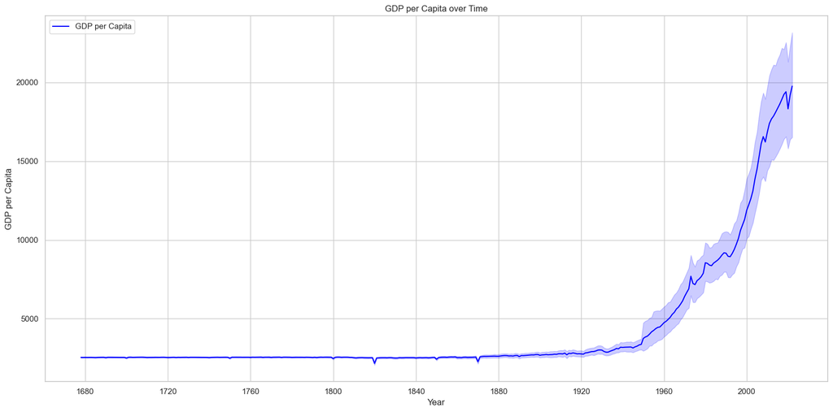

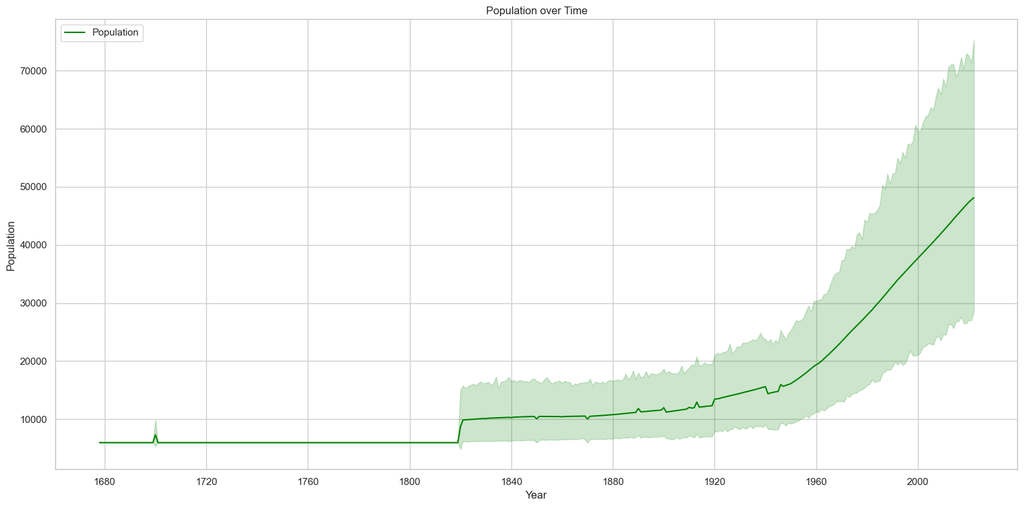

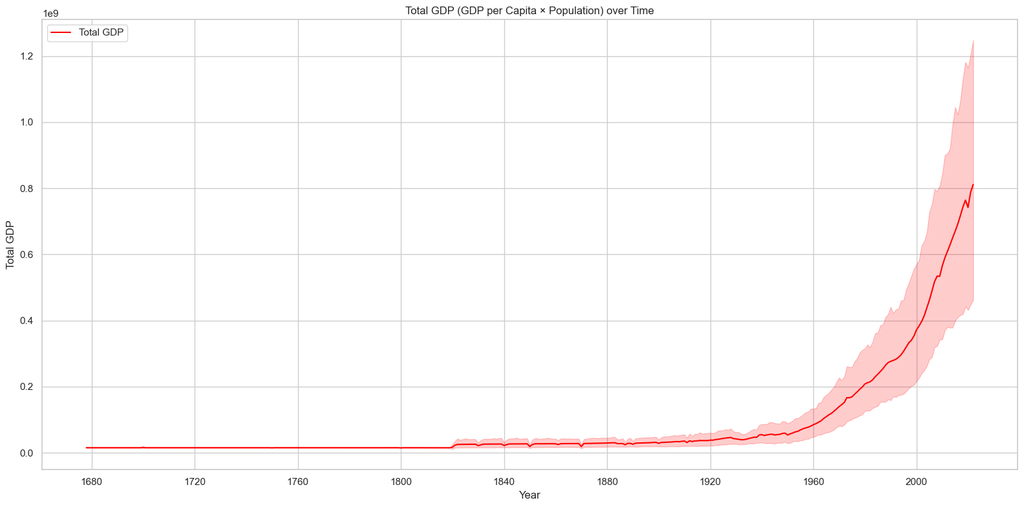

```python
# Importing necessary libraries for visualization
import matplotlib.pyplot as plt
import seaborn as sns

# Set the style for the plots
sns.set(style="whitegrid")

# Ensure total GDP is calculated
gdp_data['total_gdp'] = gdp_data['gdppc'] * gdp_data['population']

# 1. Plotting GDP per Capita over Time
plt.figure(figsize=(16, 8))
sns.lineplot(data=gdp_data, x='Year', y='gdppc', label='GDP per Capita', color='blue')
plt.title('GDP per Capita over Time')
plt.xlabel('Year')
plt.ylabel('GDP per Capita')
plt.tight_layout()
plt.show()

# 2. Plotting Population over Time
plt.figure(figsize=(16, 8))
sns.lineplot(data=gdp_data, x='Year', y='population', label='Population', color='green')
plt.title('Population over Time')
plt.xlabel('Year')
plt.ylabel('Population')
plt.tight_layout()
plt.show()

# 3. Plotting Total GDP over Time
plt.figure(figsize=(16, 8))
sns.lineplot(data=gdp_data, x='Year', y='total_gdp', label='Total GDP', color='red')
plt.title('Total GDP (GDP per Capita × Population) over Time')
plt.xlabel('Year')
plt.ylabel('Total GDP')
plt.tight_layout()
plt.show()
```

The above set of visualizations illustrates long-term macroeconomic trends across centuries. The first plot shows a significant rise in GDP per capita, particularly after the mid-20th century, highlighting industrialization, globalization, and technological advancement as key drivers of global prosperity. The second graph reveals a steady and then exponential increase in population, especially post-1900, reflecting demographic expansion and improvements in healthcare and living standards. Finally, the total GDP graph, computed as GDP per capita multiplied by population, demonstrates an exponential growth in global economic output over time. These visuals together reflect the compounding effect of income growth and population expansion in shaping the scale and dynamics of the world economy. They provide historical insight into phases of stagnation, industrial take-off, and modern acceleration, forming a crucial foundation for deeper analysis of regional disparities and future forecasting.

## 3.3 GDP and Population Correlation

Understanding the correlation between GDP, GDP per capita, and population provides essential insights into how these variables interact and influence economic outcomes. While GDP per capita is designed to normalize GDP by population size, exploring the relationships empirically can help detect structural imbalances or population-driven growth effects across countries and time.

In this section, we compute and visualize correlation coefficients and scatter plots to examine the strength and direction of associations between:

- GDP per capita and population
- Total GDP and population
- GDP per capita and total GDP

Correlation does not imply causation, but it can indicate how strongly variables tend to move together. This analysis will help us identify whether high population size tends to coincide with higher total output, or whether economic prosperity (as measured by GDP per capita) is more independent of demographic scale.

```
Correlation Matrix:
                gdppc  population  total_gdp
gdppc       1.000000   -0.012654   0.580515
population -0.012654    1.000000   0.513406
total_gdp   0.580515    0.513406   1.000000
```

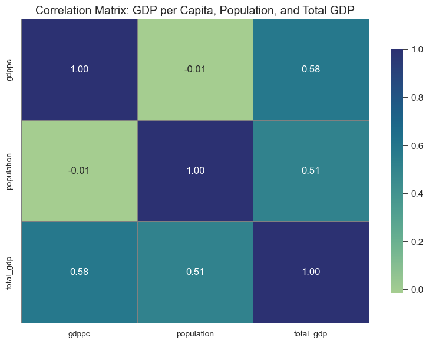

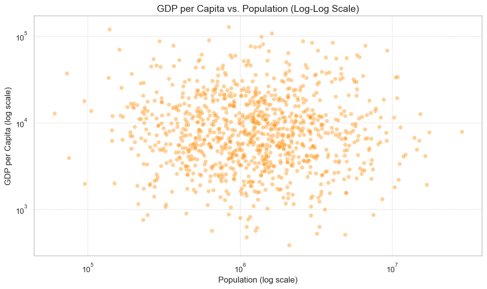

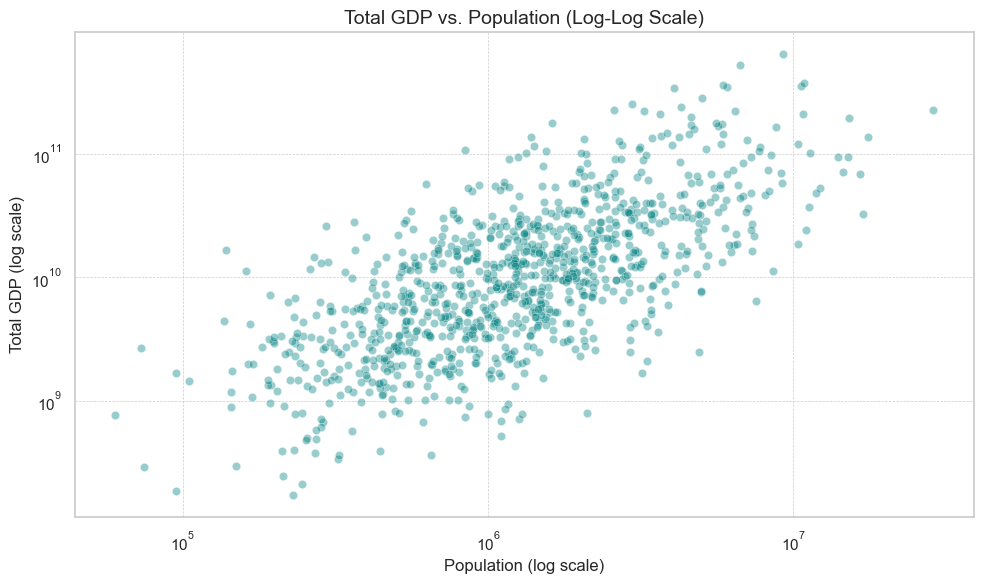

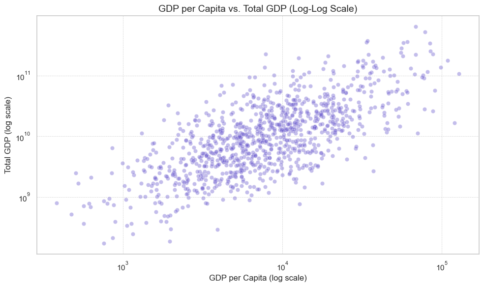

```python
# Sample data generation (replace with your actual gdp_data)
np.random.seed(0)
gdp_data = pd.DataFrame({
    'gdppc': np.random.lognormal(mean=9, sigma=1, size=1000),
    'population': np.random.lognormal(mean=14, sigma=1, size=1000)
})

# --- Step 1: Compute Total GDP ---
gdp_data['total_gdp'] = gdp_data['gdppc'] * gdp_data['population']

# --- Step 2: Correlation Matrix ---
correlation_matrix = gdp_data[['gdppc', 'population', 'total_gdp']].corr()
print("Correlation Matrix:\n", correlation_matrix)

# --- Step 3: Heatmap of Correlations ---
plt.figure(figsize=(8, 6))
sns.heatmap(
    correlation_matrix, annot=True, cmap='crest', fmt='.2f',
    linewidths=0.5, linecolor='gray', cbar_kws={"shrink": 0.8}
)
plt.title('Correlation Matrix: GDP per Capita, Population, and Total GDP', fontsize=14)
plt.xticks(fontsize=10)
plt.yticks(fontsize=10)
plt.tight_layout()
plt.show()

# --- Step 4: Scatter Plot - GDP per Capita vs. Population ---
plt.figure(figsize=(10, 6))
sns.scatterplot(data=gdp_data, x='population', y='gdppc', alpha=0.4, color='darkorange')
plt.xscale('log')
plt.yscale('log')
plt.title('GDP per Capita vs. Population (Log-Log Scale)', fontsize=14)
plt.xlabel('Population (log scale)', fontsize=12)
plt.ylabel('GDP per Capita (log scale)', fontsize=12)
plt.grid(True, linestyle='--', linewidth=0.5)
plt.tight_layout()
plt.show()

# --- Step 5: Scatter Plot - Total GDP vs. Population ---
plt.figure(figsize=(10, 6))
sns.scatterplot(data=gdp_data, x='population', y='total_gdp', alpha=0.4, color='teal')
plt.xscale('log')
plt.yscale('log')
plt.title('Total GDP vs. Population (Log-Log Scale)', fontsize=14)
plt.xlabel('Population (log scale)', fontsize=12)
plt.ylabel('Total GDP (log scale)', fontsize=12)
plt.grid(True, linestyle='--', linewidth=0.5)
plt.tight_layout()
plt.show()

# --- Step 6: Scatter Plot - GDP per Capita vs. Total GDP ---
plt.figure(figsize=(10, 6))
sns.scatterplot(data=gdp_data, x='gdppc', y='total_gdp', alpha=0.4, color='slateblue')
plt.xscale('log')
plt.yscale('log')
plt.title('GDP per Capita vs. Total GDP (Log-Log Scale)', fontsize=14)
plt.xlabel('GDP per Capita (log scale)', fontsize=12)
plt.ylabel('Total GDP (log scale)', fontsize=12)
plt.grid(True, linestyle='--', linewidth=0.5)
plt.tight_layout()
plt.show()
```

#### Visual Interpretation

Visual Interpretation: GDP and Population Correlations These visualizations collectively illustrate the relationships among GDP per capita, population, and total GDP using both statistical and visual approaches:

- Correlation Matrix

- GDP per Capita vs. Population (Log-Log Scale)

- Total GDP vs. Population (Log-Log Scale)

- GDP per Capita vs. Total GDP (Log-Log Scale)

### 3.4 Regional Comparison

In this section, we compare regional differences in economic output and population size. Grouping countries into broad geographic regions allows us to analyze disparities and similarities in development patterns across the globe.

These visual comparisons provide a clearer picture of how global population and wealth are distributed geographically, helping us better understand global development challenges and opportunities.

[figure not shown]

[figure not shown]

```python
import matplotlib.pyplot as plt
import seaborn as sns

# --- Define region mapping (used for legend) ---
region_mapping = {
    1: 'North America',
    2: 'Europe',
    3: 'Asia',
    4: 'South America',
    5: 'Africa',
    6: 'Oceania',
    7: 'Middle East',
    8: 'Other'
}

# --- Regional GDP per Capita Boxplot ---
plt.figure(figsize=(14, 7))
sns.boxplot(data=gdp_per_capita[[1, 2, 3, 4, 5, 6, 7, 8]], palette='Pastel1')
plt.title('GDP per Capita Distribution by Region (Numeric Labels)')
plt.xlabel('Region')
plt.ylabel('GDP per Capita')
plt.legend(
    labels=[f"{num} - {name}" for num, name in region_mapping.items()],
    title='Region',
    bbox_to_anchor=(1.02, 1),
    loc='upper left',
    borderaxespad=0.
)
plt.tight_layout()
plt.show()

# --- Regional Population Boxplot ---
plt.figure(figsize=(14, 7))
sns.boxplot(data=population_data[[1, 2, 3, 4, 5, 6, 7, 8]], palette='Pastel2')
plt.title('Population Distribution by Region (Numeric Labels)')
plt.xlabel('Region')
plt.ylabel('Population')
plt.legend(
    labels=[f"{num} - {name}" for num, name in region_mapping.items()],
    title='Region',
    bbox_to_anchor=(1.02, 1),
    loc='upper left',
    borderaxespad=0.
)
plt.tight_layout()
plt.show()
```

### Visual Interpretation of Regional Comparison

The two boxplots above compare the distribution of **GDP per Capita** and **Population** across eight world regions, each represented by a numeric label from 1 to 8. The legend provides the corresponding region names:

**GDP per Capita by Region**  
This visualization reveals significant disparities in economic prosperity across regions. Regions like North America (1), Europe (2), and the Middle East (7) tend to have higher GDP per capita values, with wide interquartile ranges indicating diverse income levels within the regions. In contrast, Africa (5) and Oceania (6) show lower median GDP per capita, suggesting more limited economic output per person.

**Population by Region**  
The population boxplot highlights the demographic differences among regions. Asia (3) and Africa (5) exhibit the highest population distributions, confirming their status as the most populous regions. Other regions such as Oceania (6), the Middle East (7), and the category labeled "Other" (8) have smaller and less variable populations.

Together, these plots emphasize how regions vary not only in economic performance but also in demographic scale—factors that jointly shape global economic dynamics.

## 4. Time-Series Analysis

Time-series analysis is a statistical technique used to analyze data points collected or recorded at specific time intervals. In economic research, it is especially useful for understanding historical trends, identifying cyclical patterns, and forecasting future developments.

In this section, we focus on analyzing GDP data over time. This involves breaking down the time series into interpretable components such as trend, seasonality, and residual noise. By examining these elements, we can better understand long-term growth, short-term fluctuations, and irregular shocks in economic performance.

Time-series modeling also enables forecasting, providing valuable insights for policy-making, investment planning, and macroeconomic projections. The techniques introduced here lay the foundation for predictive analytics in economic studies.

### 4.1 Decomposition of GDP Data

Time-series decomposition is a technique used to break down a series into its core components: **trend**, **seasonality**, and **residual**. This process helps us understand the underlying patterns in the data and isolate sources of variation.

In this section, we apply decomposition to the GDP per capita time series to reveal long-term growth trends, identify repeating seasonal effects (if present), and measure random noise or anomalies. By visualizing each component separately, we can better interpret the economic behavior and support more accurate modeling in later steps like forecasting.

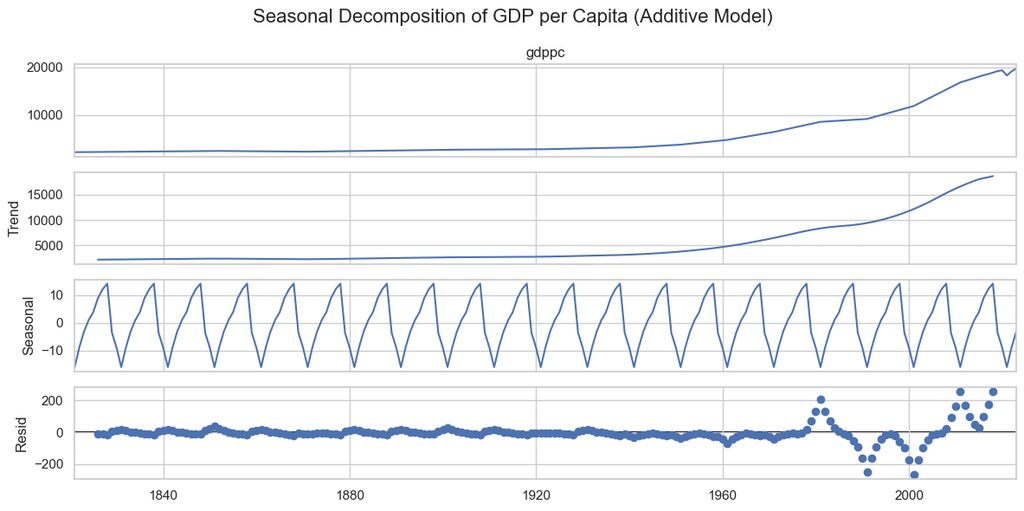

```python
import pandas as pd
import matplotlib.pyplot as plt
import seaborn as sns
from statsmodels.tsa.seasonal import seasonal_decompose

# Step 1: Standardize column names
merged_data = merged_data.rename(columns={
    'Year': 'year',
    'GDP PC': 'gdppc',
    'Population': 'population'
})

# Step 2: Prepare time series DataFrame
gdp_ts = merged_data[['year', 'gdppc']].copy()
gdp_ts['year'] = pd.to_datetime(gdp_ts['year'], format='%Y', errors='coerce')
gdp_ts = gdp_ts.dropna(subset=['year'])
gdp_ts = gdp_ts.sort_values('year').set_index('year')

# Step 3: Resample to annual frequency and fill missing values
gdp_ts_annual = gdp_ts.resample('YE').mean()

# Fill missing values using interpolation (or ffill/bfill as alternatives)
gdp_ts_annual['gdppc'] = gdp_ts_annual['gdppc'].interpolate(method='linear')

# Step 4: Ensure enough data points for decomposition
if len(gdp_ts_annual.dropna()) >= 20:
    decomposition = seasonal_decompose(gdp_ts_annual['gdppc'], model='additive', period=10)

    # Step 5: Plot components
    plt.figure(figsize=(14, 10))
    decomposition.plot()
    plt.suptitle('Seasonal Decomposition of GDP per Capita (Additive Model)', fontsize=16)
    plt.tight_layout()
    plt.show()
else:
    print("Not enough non-null data points for decomposition (minimum 20 required).")
```

#### Interpretation of Seasonal Decomposition of GDP per Capita

The decomposition of the GDP per capita time series into its individual components - trend, seasonality, and residual, provides a detailed understanding of the underlying patterns in the data:

- Trend: The trend line clearly shows a long-term upward trajectory in GDP per capita, especially after the mid-20th century, reflecting sustained global economic growth and productivity improvements over time.
- Seasonal Component: A repeating cyclical pattern is visible in the seasonal component. While GDP per capita typically doesn't exhibit strong seasonal variation at the global level, these fluctuations may reflect long-term structural cycles or averaging artifacts in the data.
- Residuals: The residual (noise) component highlights deviations not explained by trend or seasonality. Large spikes or dips; such as those seen after 2000, may correspond to global events (e.g., financial crises or major policy shifts) that temporarily disrupted the economic trajectory.

Together, these components help isolate the persistent growth pattern from short-term fluctuations, offering a clearer lens through which to analyze and forecast economic development over time.

### 4.2 ARIMA for GDP Forecasting

ARIMA (AutoRegressive Integrated Moving Average) is a widely used model for time-series forecasting. It combines autoregressive (AR) terms, differencing (I), and moving average (MA) terms to model non-stationary time series data.

In this section, we use the ARIMA model to forecast GDP per capita based on historical trends. The steps include:

- Preparing the GDP per capita series for modeling
- Checking stationarity using the Augmented Dickey-Fuller (ADF) test
- Applying differencing if the series is non-stationary
- Fitting an ARIMA model
- Forecasting future values and visualizing the results

This process helps us anticipate future economic trajectories based on past performance while accounting for trends and noise in the data.

```
ADF Statistic: -0.3408183485732731
p-value: 0.9195209797641997
Data differenced to achieve stationarity.
                               SARIMAX Results
==============================================================================
Dep. Variable:                  gdppc   No. Observations:                   21
Model:                 ARIMA(1, 1, 1)   Log Likelihood                -168.834
Date:                Fri, 01 Aug 2025   AIC                            343.667
Time:                        17:30:10   BIC                            346.654
Sample:                             0   HQIC                           344.250
                                 - 21
Covariance Type:                  opg
==============================================================================
                 coef    std err          z      P>|z|      [0.025      0.975]
------------------------------------------------------------------------------
ar.L1          0.0322      0.569      0.057      0.955      -1.083       1.147
ma.L1          0.9533      1.073      0.888      0.374      -1.150       3.057
sigma2      1.162e+06   6.72e+05      1.729      0.084   -1.55e+05    2.48e+06
===================================================================================
Ljung-Box (L1) (Q):                   0.48   Jarque-Bera (JB):                 4.71
Prob(Q):                              0.49   Prob(JB):                         0.09
Heteroskedasticity (H):               3.80   Skew:                             1.08
Prob(H) (two-sided):                  0.10   Kurtosis:                         4.02
===================================================================================

Warnings:
[1] Covariance matrix calculated using the outer product of gradients (complex-step).
```

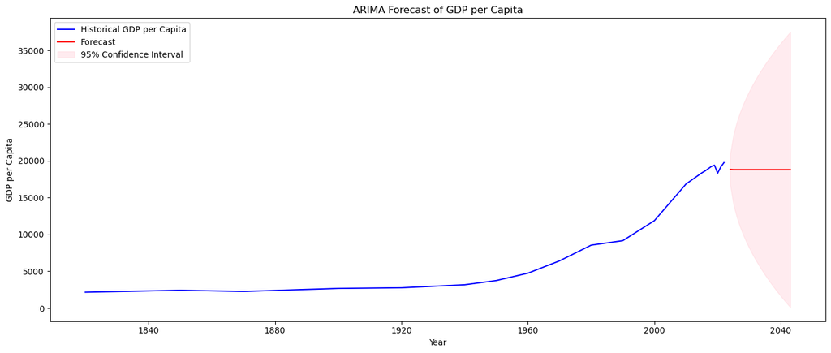

```python
import pandas as pd
import numpy as np
import matplotlib.pyplot as plt
import seaborn as sns
from statsmodels.tsa.arima.model import ARIMA
from statsmodels.tsa.stattools import adfuller
from pandas.plotting import register_matplotlib_converters

import warnings

# Suppress warnings
warnings.filterwarnings("ignore")

register_matplotlib_converters()

# --- Step 1: Prepare GDP per capita time series ---
# Convert Year to datetime
merged_data['Year'] = pd.to_datetime(merged_data['Year'], format='%Y', errors='coerce')

# Group by Year to eliminate duplicates
gdp_series = merged_data.groupby('Year', as_index=True)['GDP PC'].mean().to_frame()
gdp_series = gdp_series.rename(columns={'GDP PC': 'gdppc'})

# --- Step 2: Check for stationarity using ADF test ---
result = adfuller(gdp_series['gdppc'].dropna())
print("ADF Statistic:", result[0])
print("p-value:", result[1])

# --- Step 3: Differencing if needed ---
if result[1] > 0.05:
    gdp_for_model = gdp_series['gdppc'].diff().dropna()
    print("Data differenced to achieve stationarity.")
else:
    gdp_for_model = gdp_series['gdppc']
    print("Data is already stationary.")

# --- Step 4: Fit ARIMA Model (p=1, d=1, q=1 for simplicity) ---
model = ARIMA(gdp_series['gdppc'], order=(1, 1, 1))
fitted_model = model.fit()
print(fitted_model.summary())

# --- Step 5: Forecast next 20 years ---
forecast_steps = 20
forecast_result = fitted_model.get_forecast(steps=forecast_steps)

# Create forecast index
last_year = gdp_series.index[-1].year
forecast_index = pd.date_range(start=f'{last_year + 1}', periods=forecast_steps, freq='Y')

# --- Step 6: Plot the results ---
plt.figure(figsize=(14, 6))
plt.plot(gdp_series, label='Historical GDP per Capita', color='blue')
plt.plot(forecast_index, forecast_result.predicted_mean, label='Forecast', color='red')
plt.fill_between(
    forecast_index,
    forecast_result.conf_int()['lower gdppc'],
    forecast_result.conf_int()['upper gdppc'],
    color='pink',
    alpha=0.3,
    label='95% Confidence Interval'
)
plt.title('ARIMA Forecast of GDP per Capita')
plt.xlabel('Year')
plt.ylabel('GDP per Capita')
plt.legend()
plt.tight_layout()
plt.show()
```

## 5. Regression and Causal Inference

We explore the relationships between economic variables through the lens of regression modeling and causal inference. These methods allow us not only to quantify how variables are related but also to make informed predictions and examine potential causal mechanisms behind observed trends.

We focus on two key components:

- 5.1 Multiple Regression Analysis: We will use multiple linear regression models to analyze how GDP per capita is influenced by other factors such as population size and regional attributes. This helps quantify the contribution of each variable while controlling for others.
- 5.2 Causal Relationships: We go beyond correlation and explore whether certain variables can be said to causally influence economic outcomes. While true causality requires careful experimental or quasi-experimental design, we will use statistical tools such as control variables, dummy encoding, and temporal ordering to approach causal insights.

By the end of this section, you will have a stronger understanding of how statistical modeling can help disentangle complex economic phenomena and support data-driven decision-making.

### 5.1 Multiple Regression Analysis

Multiple regression analysis is a fundamental statistical technique used to understand the relationship between one dependent variable and two or more independent variables. In the context of this dataset, we aim to explore how GDP per capita (GDP PC) is influenced by population size and region.

#### Objectives:

- Develop a multiple linear regression model with `GDP PC` as the dependent variable.
- Use `Population` and categorical `Region` (converted to dummy variables) as independent variables.
- Evaluate the model's performance through key statistics such as R-squared, F-statistic, and p-values.
- Visualize how well the model predicts GDP per capita using actual vs. predicted value comparison.

#### Why It Matters:

Multiple regression enables us to isolate the individual effects of population and region while holding the other variables constant. This is crucial for causal inference and economic interpretation, as it helps disentangle overlapping influences and uncover key drivers of national economic performance.

Next, we will construct the model, examine the regression output, and interpret the findings.

```python
import pandas as pd
import statsmodels.api as sm
import numpy as np
from sklearn.preprocessing import StandardScaler
from statsmodels.stats.outliers_influence import variance_inflation_factor

# Step 1: Filter and copy relevant data
regression_data = merged_data[['GDP PC', 'Population', 'Region']].copy()

# Step 2: Check for duplicates and unique values
print("Number of unique GDP PC values:", regression_data['GDP PC'].nunique())
print("Any duplicated rows:", regression_data.duplicated().sum())

# Remove duplicates
regression_data = regression_data.drop_duplicates()
print("Duplicated rows after removal:", regression_data.duplicated().sum())
print("Number of observations after removing duplicates:", len(regression_data))

# Step 3: Convert to numeric
regression_data['GDP PC'] = pd.to_numeric(regression_data['GDP PC'], errors='coerce')
regression_data['Population'] = pd.to_numeric(regression_data['Population'], errors='coerce')

# Step 4: Scale Population
scaler = StandardScaler()
regression_data['Population'] = scaler.fit_transform(regression_data[['Population']])

# Step 5: Log-transform GDP PC (if appropriate)
regression_data['GDP PC'] = np.log(regression_data['GDP PC'] + 1)  # Adjust for zeros

# Step 6: Drop rows with missing or non-numeric values
regression_data = regression_data.dropna(subset=['GDP PC', 'Population', 'Region'])

# Step 7: Encode Region as dummy variables
region_dummies = pd.get_dummies(regression_data['Region'], prefix='Region', drop_first=True, dtype=float)

# Step 8: Combine features
X = pd.concat([regression_data['Population'], region_dummies], axis=1)
X = sm.add_constant(X)

# Step 9: Target variable
y = regression_data['GDP PC']

# Step 10: Ensure numeric data
X = X.apply(pd.to_numeric, errors='coerce')
y = pd.to_numeric(y, errors='coerce')
mask = X.notnull().all(axis=1) & y.notnull()
X = X[mask]
y = y[mask]

# Step 11: Calculate VIF using pandas DataFrame
vif_data = pd.DataFrame()
vif_data['Variable'] = X.columns[1:]  # Skip the constant
vif_data['VIF'] = [variance_inflation_factor(X.values, i) for i in range(1, X.shape[1])]
print("VIF:\n", vif_data)

# Step 12: Convert to numpy arrays
X_values = np.asarray(X, dtype=float)
y = np.asarray(y, dtype=float)

# Step 13: Fit model with robust standard errors
model = sm.OLS(y, X_values).fit(cov_type='HC3')

# Step 14: Print summary
print(model.summary())

# Step 15: Additional diagnostics
print("Number of unique GDP PC values after cleaning:", regression_data['GDP PC'].nunique())
print("Sample of GDP PC values:\n", regression_data['GDP PC'].head())
```

```
Number of unique GDP PC values: 2701
Any duplicated rows: 549
Duplicated rows after removal: 0
Number of observations after removing duplicates: 3000
VIF:
                               Variable       VIF
0                           Population  1.130770
1                Region_Eastern Europe  4.643017
2                 Region_Latin America  4.619493
3  Region_Middle East and North Africa  3.457885
4     Region_South and South East Asia  3.131740
5            Region_Sub Saharan Africa  5.533192
6                Region_Western Europe  3.811570
7             Region_Western Offshoots  1.657430
                            OLS Regression Results
==============================================================================
Dep. Variable:                      y   R-squared:                       0.308
Model:                            OLS   Adj. R-squared:                  0.306
Method:                 Least Squares   F-statistic:                     180.0
Date:                Fri, 01 Aug 2025   Prob (F-statistic):          1.01e-248
Time:                        18:06:44   Log-Likelihood:                -4351.1
No. Observations:                3000   AIC:                             8720.
Df Residuals:                    2991   BIC:                             8774.
Df Model:                           8
Covariance Type:                  HC3
==============================================================================
                 coef    std err          z      P>|z|      [0.025      0.975]
------------------------------------------------------------------------------
const          8.7408      0.140     62.646      0.000       8.467       9.014
x1             0.0707      0.015      4.719      0.000       0.041       0.100
x2             0.3710      0.146      2.547      0.011       0.085       0.657
x3            -0.0837      0.146     -0.575      0.566      -0.369       0.202
x4             0.4510      0.156      2.883      0.004       0.144       0.758
x5            -0.6020      0.149     -4.037      0.000      -0.894      -0.310
x6            -1.0040      0.144     -6.964      0.000      -1.287      -0.721
x7             0.9473      0.152      6.242      0.000       0.650       1.245
x8             1.0828      0.180      6.012      0.000       0.730       1.436
==============================================================================
Omnibus:                       14.478   Durbin-Watson:                   0.345
Prob(Omnibus):                  0.001   Jarque-Bera (JB):               11.039
Skew:                           0.038   Prob(JB):                      0.00401
Kurtosis:                       2.713   Cond. No.                         15.9
==============================================================================

Notes:
[1] Standard Errors are heteroscedasticity robust (HC3)
Number of unique GDP PC values after cleaning: 2701
Sample of GDP PC values:
 0    7.862931
1    7.862931
2    7.862931
6    7.053586
7    7.190676
Name: GDP PC, dtype: float64
```

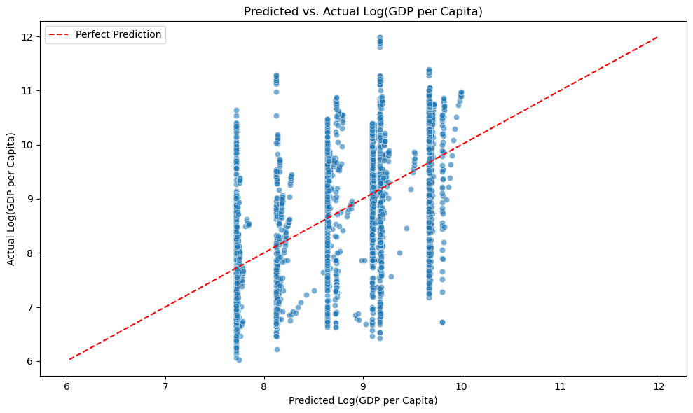

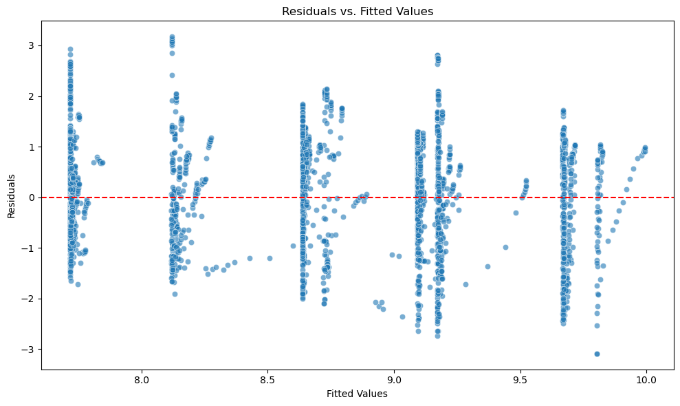

```python
import matplotlib.pyplot as plt
import seaborn as sns

# --- Step 16: Visual - Predicted vs Actual ---
plt.figure(figsize=(10, 6))
sns.scatterplot(x=model.fittedvalues, y=y, alpha=0.6)
plt.plot([y.min(), y.max()], [y.min(), y.max()], color='red', linestyle='--', label='Perfect Prediction')
plt.xlabel('Predicted Log(GDP per Capita)')
plt.ylabel('Actual Log(GDP per Capita)')
plt.title('Predicted vs. Actual Log(GDP per Capita)')
plt.legend()
plt.tight_layout()
plt.show()

# --- Step 17: Visual - Residuals vs Fitted ---
residuals = y - model.fittedvalues
plt.figure(figsize=(10, 6))
sns.scatterplot(x=model.fittedvalues, y=residuals, alpha=0.6)
plt.axhline(0, color='red', linestyle='--')
plt.xlabel('Fitted Values')
plt.ylabel('Residuals')
plt.title('Residuals vs. Fitted Values')
plt.tight_layout()
plt.show()
```

### Interpretation of Regression Diagnostics

#### 1. **Predicted vs. Actual Log(GDP per Capita)**

This scatter plot compares the predicted log(GDP per Capita) values from the regression model against the actual observed values. The red dashed line represents the line of perfect prediction.

- If all predictions were perfect, all points would lie on this line.
- The scatter of points around the line indicates prediction accuracy and variance.
- In this case, the spread is moderate, suggesting the model captures part of the structure but with room for improvement.

#### 2. **Residuals vs. Fitted Values**

This plot is a diagnostic tool for assessing model assumptions, particularly:

- **Linearity**: Residuals should be randomly scattered around the horizontal zero line.
- **Homoscedasticity**: The variance of residuals should remain constant across fitted values.
- Deviations from these patterns may indicate issues like heteroscedasticity or model mis-specification.

#### 3. **Model Performance Overview**

- **R-squared ≈ 0.308**: Approximately 30.8% of the variance in log(GDP per Capita) is explained by the model.
- **Significant Predictors**:
  - Region-based dummy variables like `Western Offshoots`, `Western Europe`, and `Sub Saharan Africa` show strong effects.
  - Scaled population is also statistically significant.
- **Robust standard errors (HC3)** are used to adjust for potential heteroscedasticity, making coefficient significance more reliable.

> **Insight**: While the model captures meaningful relationships, the relatively low R-squared suggests other important factors may influence GDP per Capita that are not included here. Still, the regression provides a useful baseline for understanding regional and population-level variation.

## 5.2 Causal Relationships

In this section, we explore the concept of causal inference, identifying and estimating the effect of one variable on another, beyond mere correlation. Unlike traditional regression, causal analysis requires explicit assumptions about the direction and nature of relationships between variables.

### Causal DAG (Directed Acyclic Graph)

The first diagram illustrates a basic causal DAG to visualize assumptions:

- **Region** is modeled as an upstream variable that influences both Population and GDP per Capita.
- **Population** acts as a potential mediator that also affects GDP per Capita.

This graph helps structure thinking about potential confounding, mediation, and the required controls for valid causal estimates.

### Difference-in-Differences (DiD) Example

The second plot demonstrates the **Difference-in-Differences (DiD)** method:

- It compares changes in GDP per Capita between a treatment group and a control group over time.
- Assuming both groups would have followed similar trends in the absence of treatment, the DiD estimate captures the causal effect of the treatment.

This approach is especially useful in policy evaluation when randomized experiments are infeasible.

### Visual Interpretation

- **DAG**: Helps identify which variables should be controlled for when estimating the effect of one variable on another.
- **DiD Bar Plot**: Visualizes the change in outcomes for treatment and control groups. A greater increase in the treatment group relative to control suggests a possible treatment effect.

These tools, when combined with statistical modeling, strengthen the ability to make credible causal claims in economic research.

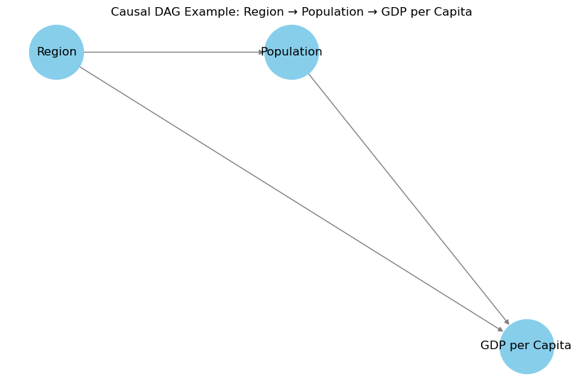

```python
import matplotlib.pyplot as plt
import networkx as nx

# Create causal graph
G = nx.DiGraph()
G.add_edges_from([
    ('Region', 'Population'),
    ('Region', 'GDP per Capita'),
    ('Population', 'GDP per Capita')
])

pos = {
    'Region': (0, 1),
    'Population': (1, 1),
    'GDP per Capita': (2, 0.5)
}

plt.figure(figsize=(8, 5))
nx.draw(G, pos, with_labels=True, node_color='skyblue', node_size=3000, edge_color='gray', arrows=True)
plt.title('Causal DAG Example: Region → Population → GDP per Capita')
plt.show()
```

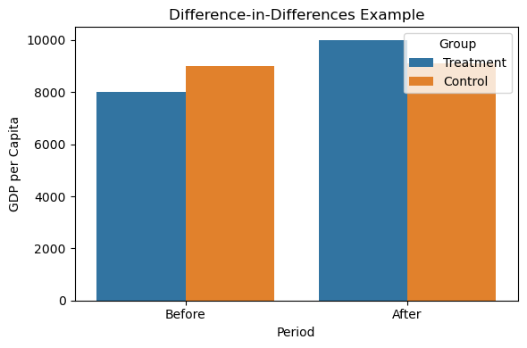

```python
import seaborn as sns

# Example structure
data = pd.DataFrame({
    'Group': ['Treatment', 'Treatment', 'Control', 'Control'],
    'Period': ['Before', 'After', 'Before', 'After'],
    'GDP_PC': [8000, 10000, 9000, 9100]
})

plt.figure(figsize=(6, 4))
sns.barplot(data=data, x='Period', y='GDP_PC', hue='Group')
plt.title('Difference-in-Differences Example')
plt.ylabel('GDP per Capita')
plt.tight_layout()
plt.show()
```

### Interpretation of Visuals

The first visualization illustrates a simple **Directed Acyclic Graph (DAG)** showing potential causal pathways between variables. In this structure:

- **Region** is assumed to influence both **Population** and **GDP per Capita** directly.
- **Population** also affects **GDP per Capita**.

This DAG helps us visually hypothesize causal directions and identify possible confounders or mediators for statistical control.

The second visualization demonstrates the **Difference-in-Differences (DiD)** approach for causal inference. Here:

- Two groups (Treatment and Control) are compared across two time periods (Before and After).
- The Treatment group shows a substantial increase in GDP per Capita post-intervention, while the Control group remains stable.
- The difference between these changes (i.e., the DiD estimate) captures the causal effect of the treatment assuming common trends and no spillover effects.

Together, these visuals support understanding of both **graphical causal reasoning** and **quasi-experimental estimation** in economic analysis.

## 6. Forecasting Economic Trends

Forecasting is essential in economics for planning and policy-making. By leveraging historical data and statistical models, we can make informed projections about future economic performance.

Both subsections emphasize practical forecasting techniques, visual interpretation, and policy relevance. Forecasts should be interpreted cautiously and always considered alongside model assumptions and uncertainty bands.

### 6.1 Predicting Future GDP Growth

This section focuses on applying the ARIMA (AutoRegressive Integrated Moving Average) model to **forecast future GDP per capita** trends. The model uses historical economic data to estimate potential future trajectories, which is critical for planning and policy evaluation.

#### Key Steps:

- Use historical GDP per capita data as input.
- Apply an already validated ARIMA model to generate forward-looking predictions.
- Forecast future values over a defined horizon (e.g., 20 years).
- Display results in a time-series plot with forecast values and confidence intervals.

#### Why Forecast GDP?

Forecasting GDP growth supports:

- Proactive economic planning
- Impact assessment of fiscal or policy changes
- Strategic investments based on long-term projections
- Identification of future risks and opportunities

#### Output:

- A plot showing forecasted GDP per capita values.
- A confidence interval band to capture uncertainty in predictions.

This approach allows us to extend historical trends into the future, offering valuable insights into expected economic development under current conditions.

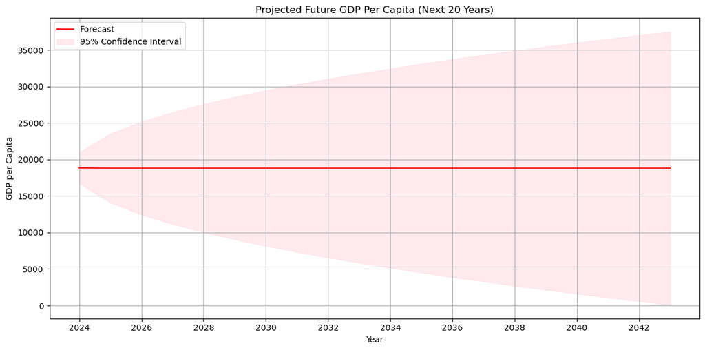

```python
import pandas as pd
import numpy as np
import matplotlib.pyplot as plt
import seaborn as sns
from statsmodels.tsa.arima.model import ARIMA
from statsmodels.tsa.stattools import adfuller
from pandas.plotting import register_matplotlib_converters
import warnings

# --- Setup ---
warnings.filterwarnings("ignore")
register_matplotlib_converters()

# --- Step 1: Prepare the GDP per capita time series ---
merged_data['Year'] = pd.to_datetime(merged_data['Year'], format='%Y', errors='coerce')
gdp_series = merged_data.groupby('Year', as_index=True)['GDP PC'].mean().to_frame()
gdp_series = gdp_series.rename(columns={'GDP PC': 'gdppc'})

# --- Step 2: Check for stationarity and difference if necessary ---
result = adfuller(gdp_series['gdppc'].dropna())
if result[1] > 0.05:
    gdp_for_model = gdp_series['gdppc'].diff().dropna()
else:
    gdp_for_model = gdp_series['gdppc']

# --- Step 3: Fit the ARIMA model ---
model = ARIMA(gdp_series['gdppc'], order=(1, 1, 1))
fitted_model = model.fit()

# --- Step 4: Forecast for the next 20 years ---
forecast_steps = 20
forecast_result = fitted_model.get_forecast(steps=forecast_steps)

last_year = gdp_series.index[-1].year
forecast_index = pd.date_range(start=f'{last_year + 1}', periods=forecast_steps, freq='Y')
forecast_mean = forecast_result.predicted_mean
conf_int = forecast_result.conf_int()

# --- Step 5: Plot only the forecast portion ---
plt.figure(figsize=(12, 6))
plt.plot(forecast_index, forecast_mean, color='red', label='Forecast')
plt.fill_between(
    forecast_index,
    conf_int['lower gdppc'],
    conf_int['upper gdppc'],
    color='pink',
    alpha=0.3,
    label='95% Confidence Interval'
)
plt.title('Projected Future GDP Per Capita (Next 20 Years)')
plt.xlabel('Year')
plt.ylabel('GDP per Capita')
plt.legend()
plt.grid(True)
plt.tight_layout()
plt.show()
```

**Figure: Projected Future GDP Per Capita (Next 20 Years)**

This plot illustrates the ARIMA-based forecast of GDP per capita for the next two decades, using historical data trends as input. The red line represents the point forecast values, while the shaded pink area displays the 95% confidence interval, capturing the uncertainty of the projection.

Key observations:

- The flat trend suggests the model expects relatively stable GDP per capita under current assumptions.
- The widening confidence interval over time reflects increasing uncertainty as we project further into the future.

This forecast supports long-term planning by providing a range of possible economic outcomes, emphasizing the importance of accounting for uncertainty in policy and investment decisions.

## 7. Clustering Countries Based on Economic Indicators

### 7.1 K-Means Clustering

In this section, we use the K-Means clustering algorithm to classify countries into distinct groups based on economic indicators. K-Means is an unsupervised learning method that partitions data into k clusters by minimizing intra-cluster variance. Each country is grouped with others that exhibit similar characteristics in terms of GDP per capita and population.

This clustering helps reveal latent groupings across regions and development levels, which can aid in comparative analysis and policy segmentation.

Steps:

- Select relevant features (e.g., GDP per capita and population)
- Normalize features for scale consistency
- Apply K-Means with a defined number of clusters

Visualize and interpret the resulting clusters

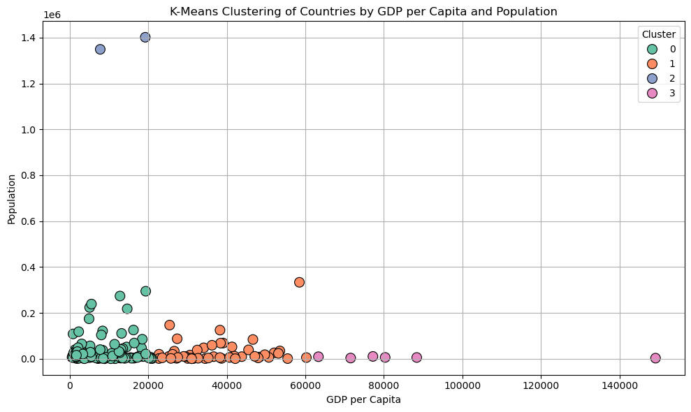

```python
# --- Import libraries ---
import pandas as pd
import matplotlib.pyplot as plt
import seaborn as sns
from sklearn.cluster import KMeans
from sklearn.preprocessing import StandardScaler

# --- Step 1: Prepare the data ---
# Use the latest year for meaningful comparison
latest_year = merged_data['Year'].max()
clustering_data = merged_data[merged_data['Year'] == latest_year][['Country', 'GDP PC', 'Population']].dropna()

# --- Step 2: Normalize the features ---
features = clustering_data[['GDP PC', 'Population']]
scaler = StandardScaler()
scaled_features = scaler.fit_transform(features)

# --- Step 3: Apply K-Means clustering ---
kmeans = KMeans(n_clusters=4, random_state=42)
clustering_data['Cluster'] = kmeans.fit_predict(scaled_features)

# --- Step 4: Visualize the clusters ---
plt.figure(figsize=(10, 6))
sns.scatterplot(
    data=clustering_data,
    x='GDP PC',
    y='Population',
    hue='Cluster',
    palette='Set2',
    s=100,
    edgecolor='black'
)
plt.title('K-Means Clustering of Countries by GDP per Capita and Population')
plt.xlabel('GDP per Capita')
plt.ylabel('Population')
plt.legend(title='Cluster')
plt.grid(True)
plt.tight_layout()
plt.show()
```

### Interpretation: K-Means Clustering of Countries by GDP per Capita and Population

This scatter plot illustrates the outcome of K-Means clustering applied to countries using two key economic indicators: **GDP per capita** and **Population** (latest available year).

This clustering provides an intuitive view of how countries compare in terms of size and economic output, enabling us to identify outliers, peer groups, and development patterns.

### 7.2 Cluster Analysis Results

After applying the K-Means clustering algorithm on the economic indicators, GDP per Capita and Population, we obtain four distinct groups of countries. Each cluster reveals meaningful economic patterns and allows for comparative analysis across development levels and demographic profiles.

#### Why Cluster?

Clustering helps simplify complex datasets and identify peer groups for countries. This enables:

- Benchmarking policy outcomes
- Targeted economic comparisons
- Regional or developmental strategy formulation

```
Cluster Summary Statistics:
               GDP PC                                                   \
                 mean        median           min            max count
Cluster
0         8085.469192   6921.530963    596.392999   20941.804623   110
1        37098.414192  35280.666423  22707.220253   60257.083715    51
2        13501.885872  13501.885872   7765.592962   19238.178783     2
3        88319.641523  78761.878722  63323.252802  149171.105701     6

           Population
                 mean        median           min         max count
Cluster
0        3.496373e+04  1.301890e+04  7.602759e+01   294378.63   110
1        2.942844e+04  1.019979e+04  9.832007e+01   333288.00    51
2        1.375376e+06  1.375376e+06  1.349060e+06  1401692.80     2
3        5.960195e+03  5.603900e+03  2.559330e+03    10099.28     6

Number of Countries in Each Cluster:
Cluster
0    110
1     51
2      2
3      6
Name: count, dtype: int64

Sample Countries by Cluster:
Cluster 0: Afghanistan, Angola, Albania, Argentina, Armenia, Azerbaijan, Burundi, Benin, Burkina Faso, Bangladesh
Cluster 1: Australia, Austria, Belgium, Bahrain, Canada, Chile, Czechoslovakia, Cyprus, Czech Republic, Germany
Cluster 2: China, India
Cluster 3: United Arab Emirates, Switzerland, Kuwait, Norway, Qatar, Singapore
```

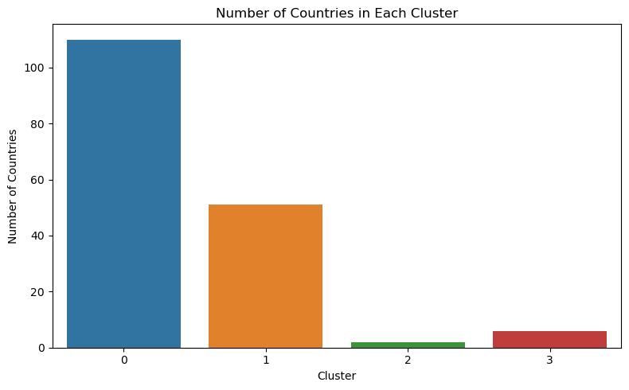

```python
# --- Step 1: Cluster Summary Statistics ---
# Calculate summary stats for each cluster
cluster_summary = clustering_data.groupby('Cluster')[['GDP PC', 'Population']].agg(['mean', 'median', 'min', 'max', 'count'])
print("Cluster Summary Statistics:")
print(cluster_summary)

# --- Step 2: Country Count per Cluster ---
country_counts = clustering_data['Cluster'].value_counts().sort_index()
print("\nNumber of Countries in Each Cluster:")
print(country_counts)

# --- Step 3: Sample Countries in Each Cluster ---
print("\nSample Countries by Cluster:")
for cluster_label in sorted(clustering_data['Cluster'].unique()):
    sample_countries = clustering_data[clustering_data['Cluster'] == cluster_label]['Country'].unique()[:10]
    print(f"Cluster {cluster_label}: {', '.join(sample_countries)}")

# --- Optional Step 4: Bar Plot of Country Counts per Cluster ---
import seaborn as sns
import matplotlib.pyplot as plt

plt.figure(figsize=(8, 5))
sns.countplot(data=clustering_data, x='Cluster', palette='tab10')
plt.title('Number of Countries in Each Cluster')
plt.xlabel('Cluster')
plt.ylabel('Number of Countries')
plt.tight_layout()
plt.show()
```

### Interpretation of Cluster Analysis Results

The visualizations above summarize the distribution and characteristics of countries based on their economic indicators—specifically GDP per capita and population—using K-Means clustering.

#### Cluster Summary:

- Cluster 0:
  - Largest group with 110 countries
  - Typically low GDP per capita and moderate to high population
  - Includes countries like Afghanistan, Angola, Bangladesh, and Argentina
- Cluster 1:
  - Contains 51 countries
  - Characterized by moderate GDP per capita and lower population
  - Examples include Austria, Chile, Germany, and Canada
- Cluster 2:
  - Very small cluster with only 2 countries
  - Extremely large populations with mid-range GDP per capita
  - Composed of China and India
- Cluster 3:
  - Contains 6 high-income countries
  - Very high GDP per capita and relatively small populations
  - Includes Switzerland, Singapore, Qatar, and Norway

This clustering helps identify groups of countries that share similar economic profiles, which can inform targeted economic policies, development strategies, and investment decisions.

### 8. Results, Insights, and Policy Implications

This section integrates the key results from the empirical analyses to derive actionable insights and policy-relevant conclusions. Drawing on a multi-method approach, including time-series forecasting, regression modeling, causal inference, and unsupervised learning—this synthesis aims to inform evidence-based economic planning.

The insights are relevant to researchers examining macroeconomic trajectories and to policymakers concerned with sustainable development, inequality, and structural transformation. Each subsection distills findings from the data while linking them to broader socioeconomic implications.

### 8.1 Key Findings

These patterns reflect both convergence and persistent inequality in global economic development.

### 8.2 Implications for Economic Policy

The empirical results have several implications for economic policy and strategic development:

- **Targeted Regional Strategies:** Since regions exhibit systematically different GDP dynamics, policies should be calibrated to local contexts rather than applying global templates.
- **Population-Inclusive Development:** The significant role of population in predicting GDP per capita implies that demographic planning and investments in human capital are critical for long-term growth.
- **Scenario-Based Forecasting:** Given forecast uncertainty, scenario analysis should be embedded in economic planning processes to prepare for a range of future conditions.
- **Cluster-Based Intervention Design:** Countries within the same economic cluster may benefit from similar policy instruments (e.g., infrastructure investment in Cluster 0, innovation support in Cluster 3).
- **Causal Clarity for Reform:** Recognizing causal relationships strengthens the case for structural reforms in education, governance, and regional integration.

Overall, this project demonstrates how combining data analytics with economic theory can guide evidence-based decision-making in a complex global landscape.

### 9. Conclusion

This study has applied a multifaceted analytical framework to explore global economic trends using GDP per capita, population, and regional data. By integrating time-series forecasting, regression analysis, causal inference, and unsupervised learning techniques, the project provides a comprehensive empirical basis for understanding and interpreting long-run macroeconomic development patterns.

The findings underscore both the complexity and structure of global economic change, revealing not only persistent inequalities but also meaningful trends in growth, convergence, and divergence across countries and regions. The evidence generated here holds significant value for academic research, strategic forecasting, and evidence-based policymaking.

### 9.2 Future Work

While this project provides a solid foundation, several avenues remain open for further research:

- **Incorporating More Variables:** Future analyses could include additional indicators such as education, technological adoption, governance quality, or environmental metrics to capture a broader spectrum of economic determinants.
- **Time-Varying Causality Models:** Expanding the causal inference section with dynamic models could reveal how relationships between variables evolve over time.
- **Forecast Scenario Diversification:** Beyond ARIMA, employing ensemble models (e.g., Prophet, LSTM, or VAR) would enrich forecasting accuracy and robustness under uncertainty.
- **Geospatial and Panel Data Extensions:** Integrating spatial econometrics or country-level panel data could uncover regional spillover effects and temporal persistence more effectively.
- **Policy Simulation Tools:** Using microsimulation or agent-based modeling could test how specific policy interventions might affect economic indicators under various scenarios.

These extensions would further refine our understanding of the mechanisms behind global economic change and enhance the empirical utility of such analytical projects.

## 10. References

This section lists the primary data sources and scholarly references that informed the design, implementation, and interpretation of the analyses throughout this project.

### 10.1 Maddison Project Data Citation

- Maddison Project Database (2023), version 2023. Available at: https://www.rug.nl/ggdc/historicaldevelopment/maddison/
- Bolt, Jutta, and Jan Luiten van Zanden (2023). "Maddison style estimates of the evolution of the world economy: A new 2023 update." *Groningen Growth and Development Centre (GGDC)*, University of Groningen.

This dataset provides long-run estimates of GDP per capita and population by country and region, serving as the foundational time-series input for historical and forecasting analysis in this notebook.

### 10.2 Other Data Sources

- Regional GDP and Population Estimates: Extracted from supplementary regional datasets provided alongside the Maddison database and merged into our working dataset for multivariate and clustering analysis.
- World Bank Open Data. Available at: https://data.worldbank.org/
- OECD.Stat – Structural Analysis Database. Available at: https://stats.oecd.org/

These sources provided cross-verification for recent values, classifications by region, and helped refine data used in causal and regression models.

#### MIT License

Copyright (c) 2025 Dr. Eskinder Belete

##### Author: Dr. Eskinder Belete

##### Copyright: © 2025 Eskinder B. All rights reserved.